# Homework 2

Ahmet Tabakoglu

22/11/2021

In this project, the training data for CBF is gathered and used for testing penalized versions of some linear regression approaches. The field of research in this project is representing the gathered data using 1D Fused Lasso and regression trees. The formula that is used for 1D Fused Lasso representation can be reached from the following [link](https://cran.r-project.org/web/packages/genlasso/vignettes/article.pdf), in section 3.1. In 1D Fused Lasso representation, the aim is to find the best λ value that yields the least error. On the other hand, in regression tree representation, the objective is to find the best maximum depth setting. After finding the coefficients and obtaining the values of predictions for each representation method, comparisons will be made by calculating the mean squared errors and using 1-NN classifier method to choose the most accurate representation technique.

## Data Manipulation

```r
library(data.table)
library(genlasso)
library(rpart)
library(rattle)
```

```r
library(e1071)
library(ggplot2)

# The training data for CBF is imported

cbftrain <- fread("C:/Users/AHMET/Desktop/CBF/CBF_TRAIN.txt")

#ID variable is added

cbftrain[,id:=1:.N]

#Class information is added

setnames(cbftrain, "V1", "class")

#Final form of the data table is shown below

head(cbftrain)
```

```
##    class         V2         V3          V4          V5         V6         V7
## 1:     1 -0.4642765 -0.5550479 -0.84284310 -0.86589548 -0.9363963 -0.8172700
## 2:     1 -0.8969721 -0.6856855 -1.35138180 -1.45866680 -1.1653456 -1.4039293
## 3:     1 -0.4646960 -0.5677389 -0.03202276 -0.63504562 -0.6028255 -0.2668563
## 4:     3 -0.1871897 -0.6208077 -0.81566070 -0.52139796 -0.7904229 -0.9675174
## 5:     2 -1.1360166 -1.3191953 -1.84462380 -0.78869178 -0.2517154 -1.4876032
## 6:     2 -0.5687087 -0.8881180 -0.04797658 -0.03803611 -0.4830683 -1.0946887
##            V8          V9        V10         V11        V12        V13
## 1: -0.2636122 -1.25804830 -1.2503934 -0.91830825 -0.9221023 -0.9844883
## 2: -1.8217996 -0.83160109 -1.0163124 -0.80353040 -1.2595048 -1.1392341
## 3: -0.2670613 -0.93104230 -0.4493819 -0.72134200 -0.3972719 -0.9621259
## 4: -1.4870063 -0.27788714 -0.8350747  0.05059104 -0.8111683 -1.2260083
## 5: -0.6687641 -0.34036037 -1.0463815 -0.31221353 -1.0314417 -1.2005780
## 6: -0.9534529 -0.03000688 -0.7954546 -0.51445458 -0.7187614 -0.5162723
##           V14        V15        V16         V17        V18        V19
```

[output cut: 132 more lines]

## Task 1: 1D Fused Lasso Representation

1D Fused Lasso representation method is applied to the training data of CBF below.

```r
#Empty lists are formed to keep the data generated in the for loop

fusedlasso <- list()
minlam <- list()

#For loop is constructed to apply 1D Fused Lasso representation method for k = 10

for (i in c(1:30)) {

    fused <- fusedlasso1d(as.matrix(cbftrain[id==i, 2:129]))
    fusedlasso[[i]] <- fused
    #Cross-validation is applied to keep the least λ value for each instance
    cv <- cv.trendfilter(fusedlasso[[i]], k = 10)
    minlam[[i]] <- cv$lambda.min

}
```

[output not shown]

A sample plot using the first instance is constructed and shown below.

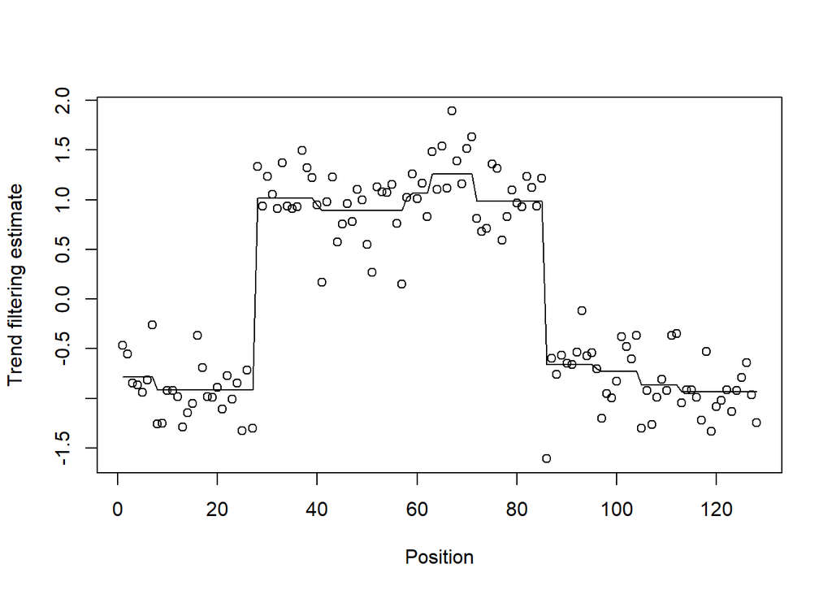

```r
plot(fusedlasso[[1]], lambda=minlam[[1]])
```

## Task 2: Regression Tree Representation

Regression tree representation method is applied to the training data of CBF below after melting the data.

```r
#The training data for CBF is melted and converted to long version for easier usage

long_cbftrain <- melt(cbftrain,id.vars=c('id','class'))
long_cbftrain[,time:=as.numeric(gsub("\\D", "", variable))-1]
long_cbftrain <- long_cbftrain[,list(id,class,time,value)]
long_cbftrain <- long_cbftrain[order(id,time)]
head(long_cbftrain)
```

```
##    id class time      value
## 1:  1     1    1 -0.4642765
## 2:  1     1    2 -0.5550479
## 3:  1     1    3 -0.8428431
## 4:  1     1    4 -0.8658955
## 5:  1     1    5 -0.9363963
## 6:  1     1    6 -0.8172700
```

```r
#Empty lists are formed to keep the data generated in the for loop

treelist <- list()
maxdep <- list()

#Range values are decided to use in the investigation of maximum depth

ranges <- list(minsplit=20, cp=0, minbucket=10, maxdepth=1:10)

#For loop is constructed to apply regression tree representation method

for (i in c(1:30)) {

    #Tune function is used to find optimal maximum depth values for each instances
    tuned <- tune(rpart, value~time, data=long_cbftrain[id==i], ranges=ranges)
    maxdep[[i]] <- tuned
    tree <- rpart(value~time, long_cbftrain[id==i], control=rpart.control(minsplit=20, minbucket=10, cp=0, maxdepth=maxdep[[i]]$best.parameters[,4]))
    treelist[[i]] <- tree

}
```

The resulting regression tree is plotted below.

[figure not shown]

```r
selected_dt <- long_cbftrain[id==1]
tree_fit <- treelist[[1]]
fancyRpartPlot(tree_fit)
```

Finally, the actual values versus the predictions made by regression tree representation method is plotted below.

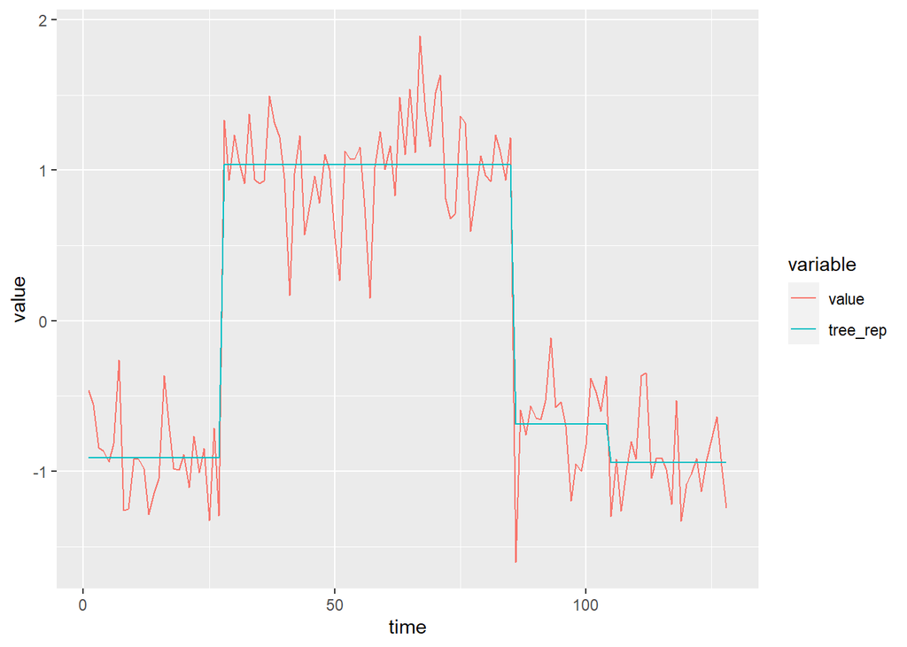

```r
selected_dt[,tree_rep:=predict(tree_fit, selected_dt)]
data_plot <- melt(selected_dt, id.vars='time', measure.vars=c('value','tree_rep'))
ggplot(data_plot,aes(x=time,y=value,color=variable)) + geom_line()
```

## Task 3: Mean Squared Errors

In this task, actual values and the predictions made using two methods are collected in the same data table and mean squared errors are calculated.

```r
#An empty list is formed to keep the data generated in the for loop

pred_values <- list()

#For loop is constructed to cluster the actual and predicted values

for (i in c(1:30)){

  series <- long_cbftrain[id==i]
  series[,tree_rep:=predict(treelist[[i]], series)]
  series[,fused_rep:=predict(fusedlasso[[i]], lambda=minlam[[i]], series)$fit]
  pred_values[[i]] <- series

}

#The first instance is shown as a sample

head(pred_values[[1]])
```

```
##    id class time      value   tree_rep  fused_rep
## 1:  1     1    1 -0.4642765 -0.9092255 -0.7841218
## 2:  1     1    2 -0.5550479 -0.9092255 -0.7841218
## 3:  1     1    3 -0.8428431 -0.9092255 -0.7841218
## 4:  1     1    4 -0.8658955 -0.9092255 -0.7841218
## 5:  1     1    5 -0.9363963 -0.9092255 -0.7841218
## 6:  1     1    6 -0.8172700 -0.9092255 -0.7841218
```

```r
#Empty lists are formed to keep the data generated in the for loop

mse_tree <- list()
mse_fused <- list()

#For loop is constructed to calculate and keep the mean squared errors

for (i in c(1:30)){

  mse_tree[[i]] <- mean((pred_values[[i]]$value - pred_values[[i]]$tree_rep)^2)
  mse_fused[[i]] <- mean((pred_values[[i]]$value - pred_values[[i]]$fused_rep)^2)

}

#Types are converted to data frame and final MSE table is formed

mse_fused <- do.call(rbind.data.frame, mse_fused)
mse_tree <- do.call(rbind.data.frame, mse_tree)
names(mse_tree)[1] <- "mse_tree"
mse <- copy(mse_tree)
mse["mse_fused"] <- mse_fused
mse["id"] <- c(1:30)
mse["class"] <- NA

for (i in c(1:30)){

  mse$class[i] <- cbftrain[i]$class

}

setDT(mse)
head(mse)
```

```
##      mse_tree  mse_fused id class
## 1: 0.09337459 0.07582339  1     1
## 2: 0.10458403 0.08875735  2     1
## 3: 0.09406769 0.07374431  3     1
## 4: 0.18345079 0.15784563  4     3
## 5: 0.15628831 0.15307345  5     2
## 6: 0.20689583 0.19097581  6     2
```

For plotting purposes, the final MSE table is melted and converted to the long format. Comparisons are made after constructing boxplots.

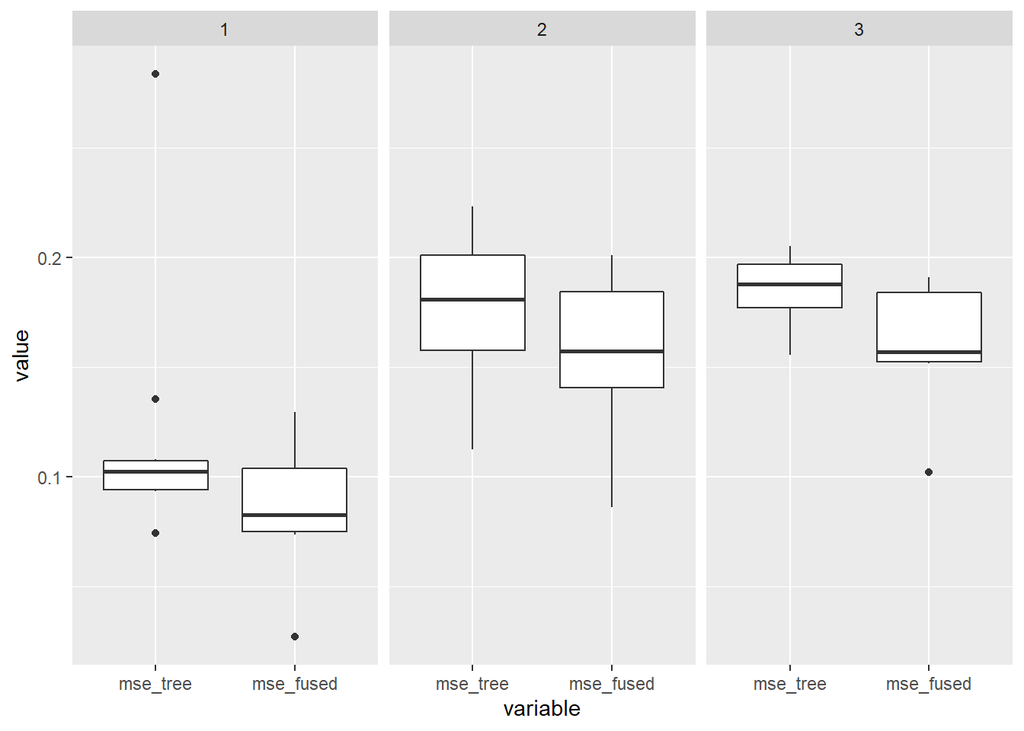

```r
long_mse <- melt(mse, id.vars =c('id','class'))
long_mse <- long_mse[order(id,variable)]
ggplot(long_mse, aes(x=variable,y=value)) + facet_wrap(~class) + geom_boxplot()
```

If the boxplots above are investigated, it is seen that the predicted values using 1D Fused Lassa method are more accurate than that of regression trees for each class type since the mean squared errors of the former are less than that of the latter.

## Task 4: 1-NN Classifier Method

In the final task, 1-NN classifier method is applied to the raw data, regression tree representation data, and fused lassa representation data separately. Then, performances are measured using accuracy of predictions and comparisons are made.

### Raw Time Series Data

```r
#A large number is set to prevent selecting the diagonal entries of the distance matrix

large_number <- 1000
trainclass <- cbftrain[,1]

#Euclidean distances for the raw data are calculated and head of the distance matrix is shown

raw_values <- cbftrain[,2:129]
euc_dist_raw <- dist(raw_values)
euc_dist_raw <- as.matrix(euc_dist_raw)
diag(euc_dist_raw) <- large_number
head(euc_dist_raw)
```

```
##             1           2           3          4          5           6
## 1 1000.000000    9.449364    9.358967   13.24577   15.84053   11.513919
## 2    9.449364 1000.000000   11.016553   11.64415   16.72213   12.470209
## 3    9.358967   11.016553 1000.000000   10.73249   17.41313    9.420593
## 4   13.245768   11.644152   10.732494 1000.00000   17.78881   14.211284
## 5   15.840525   16.722127   17.413129   17.78881 1000.00000   16.714189
## 6   11.513919   12.470209    9.420593   14.21128   16.71419 1000.000000
##           7        8        9        10        11        12       13       14
## 1  8.675663 14.20093 11.21629  8.071055  8.820555  9.960345 11.33305 11.26938
## 2  7.508033 11.44531 10.98939  7.836692 11.049433 12.366754 13.15748 11.35411
## 3 10.199629 12.07478 14.89140  9.532770 11.429615 12.245147 13.23075 15.01746
## 4 11.335166 10.32766 16.50792 11.356598 15.088093 15.999206 14.49400 16.69204
## 5 16.447398 18.74608 13.40247 16.527378 15.981794 15.130952 11.89060 15.14382
## 6 11.778372 14.41449 13.97201 11.761546 11.133898 11.556315 13.35001 14.59159
##          15        16        17        18       19        20       21       22
## 1 15.284193  8.353840 15.661988 14.794394 11.07253 14.101930 17.26329 14.15534
## 2 16.766521 10.906094 16.716342 15.385844 12.66829 11.801919 18.04283 14.90078
## 3 17.549981  9.537848 17.930999 17.157764 13.10275 12.025674 18.94719 16.87893
## 4 17.873246 12.682275 18.592423 17.934920 15.21565  9.072557 18.56769 17.90161
## 5  7.109673 15.060484  7.349398  9.829389 10.46763 18.348601 11.18996 10.44882
## 6 16.815334 11.710153 16.838100 16.788288 13.57166 14.735551 17.49074 16.44923
##         23       24        25        26        27        28        29        30
## 1  9.10022 12.34549  8.045094 10.366692 10.089682 10.419929  9.879613  8.220676
## 2 11.64037 14.99946  9.648777 12.158471 11.576478 12.198272 11.205922  9.269198
## 3 11.90997 14.46470  9.238307  8.737262  9.744871  7.761067  8.667752 11.430761
## 4 14.31722 15.97430 12.241612 11.327443 14.556190 10.151100 11.270617 13.766867
## 5 12.49306 11.45392 15.989725 16.795150 16.477706 17.421956 16.348070 14.340903
## 6 12.85238 14.52085 11.244422 12.161887  8.756060 11.662135 11.792407 12.399316
```

```r
#Neighbors of all instances are found and shown below

neighborhood_raw <- order(euc_dist_raw[1,])
neighborhood_raw
```

```
##  [1] 25 10 30 16  7 11 23  3  2 29 12 27 26 28 19  9 14 13  6 24  4 20 22  8 18
## [26] 15 17  5 21  1
```

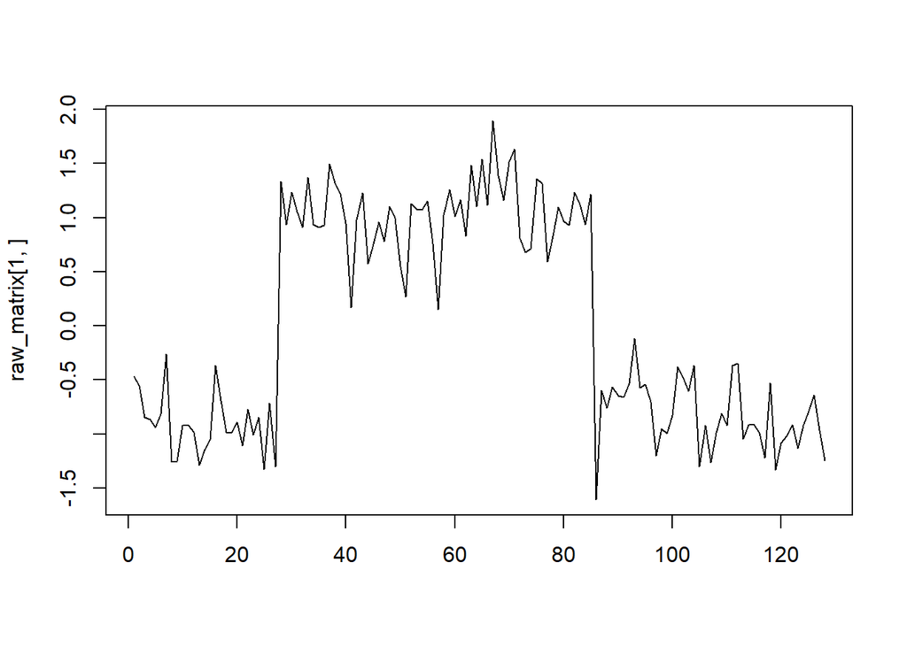

```r
#Predictions are made for classes using neighbors

neighbor_raw <- neighborhood_raw[1]
prediction_raw <- trainclass[neighbor_raw]
raw_matrix <- as.matrix(raw_values)

#Plots for raw data and the neighbors are shown below

matplot(raw_matrix[1,],type='l',col= 1)
```

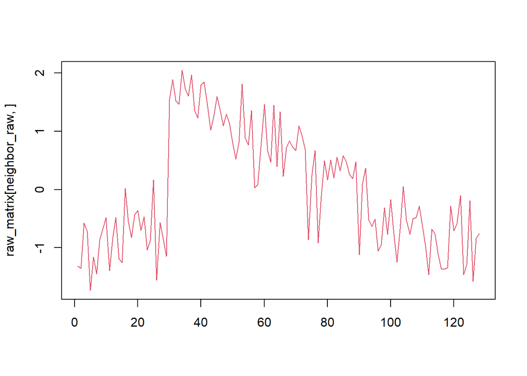

```r
matplot(raw_matrix[neighbor_raw,],type='l',col= 2)
```

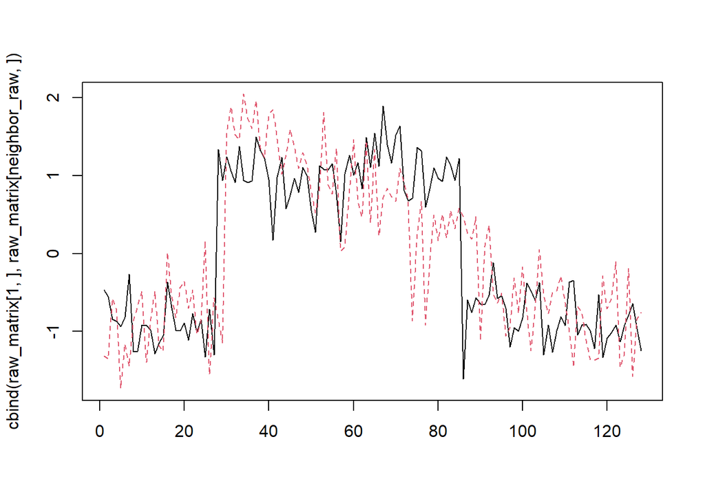

```r
matplot(cbind(raw_matrix[1,],raw_matrix[neighbor_raw,]),type='l')
```

```r
#The table representing the number of correct predictions is constructed

neig_raw <- apply(euc_dist_raw,1,order)
pred_raw <- trainclass[neig_raw[1,]]
rawtable <- copy(trainclass)
setnames(rawtable,'class','actual')
rawtable[,predicted:=pred_raw]
rawtable$is.correct = ifelse(rawtable$predicted==rawtable$actual, 1, 0)
table(rawtable$actual,rawtable$predicted)
```

```
##
##      1  2  3
##   1  8  0  2
##   2  1 11  0
##   3  2  0  6
```

```r
#Accuracy is calculated

acc_raw <- sum(rawtable$actual==rawtable$predicted)/length(rawtable$predicted)
print(acc_raw)
```

```
## [1] 0.8333333
```

### Regression Tree Representation

```r
#An empty list and a for loop is formed to keep the prediction data made using regression tree method

tree_rep <- list()

for (i in (1:30)){

  tree_rep[[i]] <- pred_values[[i]]$tree_rep

}

setDT(tree_rep)
tree_rep <- as.data.frame(t(tree_rep))

#Euclidean distances for the predictions made using regression tree method are calculated and head of the distance matrix is shown

euc_dist_tree <- dist(tree_rep)
euc_dist_tree <- as.matrix(euc_dist_tree)
diag(euc_dist_tree) <- large_number
head(euc_dist_tree)
```

```
##             V1         V2          V3          V4         V5          V6
## V1 1000.000000    7.70958    8.380584   11.402834   14.77086    9.185130
## V2    7.709580 1000.00000   10.103099   10.889667   15.52649   10.636952
## V3    8.380584   10.10310 1000.000000    8.235741   16.50514    6.654277
## V4   11.402834   10.88967    8.235741 1000.000000   16.45286   11.593783
## V5   14.770860   15.52649   16.505143   16.452862 1000.00000   15.175803
## V6    9.185130   10.63695    6.654277   11.593783   15.17580 1000.000000
##           V7        V8        V9       V10       V11       V12       V13
## V1  6.478100 12.499346  9.647833  5.734435  6.664175  7.894595 10.565905
## V2  5.147560 10.057695  8.790290  5.677672  9.408071  9.870176 12.255185
## V3  9.299874 10.096717 14.047425  8.917384 10.047698 10.532161 11.834338
## V4 10.214360  7.444941 15.250441 10.014214 13.298561 13.641279 12.099896
## V5 15.423617 17.512918 11.737775 15.446955 14.672767 13.900381  9.944823
## V6  9.879745 12.279087 12.623641  9.772909  8.736647  9.243106 11.887420
##          V14       V15       V16       V17       V18       V19       V20
## V1  9.052184 14.804830  5.790683 15.180655 13.563717  9.907706 12.111107
## V2  9.358855 15.646752  9.152081 15.718436 14.182668 11.873666  9.965604
## V3 14.132830 16.637874  8.192058 17.261567 16.112651 12.769262  9.707329
## V4 15.465835 16.688662 10.725238 17.604752 16.434784 14.150792  6.368040
## V5 13.381241  2.242625 13.823125  4.679315  7.508827  8.492966 17.061325
## V6 12.582967 15.021305  9.330173 15.567975 14.850766 12.414347 11.996963
##          V21       V22      V23      V24       V25       V26       V27
## V1 16.353713 13.173673  7.52636 10.92858  5.094767  8.331633  8.307290
## V2 16.953312 13.472546 10.06201 13.43770  7.746845 10.781735 10.221148
## V3 17.791414 16.192121 11.20075 13.09770  7.120216  6.540958  7.433177
## V4 17.065273 16.487280 12.87822 14.16500  9.776407  8.602300 12.304171
## V5  9.150842  8.641707 11.17419  9.72502 14.374873 15.448762 14.721665
## V6 16.230988 15.123125 11.70520 12.44821  8.879338  9.503185  6.204404
##          V28       V29       V30
## V1  8.139157  7.245062  6.081645
## V2 10.574685  9.434290  7.490917
## V3  4.804996  6.501595 10.387905
## V4  7.303204  8.875578 12.515094
## V5 16.238318 14.986772 13.135228
## V6  8.927085  8.547763 10.582367
```

```r
#Neighbors of all instances are found and shown below

neighborhood_tree <- order(euc_dist_tree[1,])
neighborhood_tree
```

```
##  [1] 25 10 16 30  7 11 29 23  2 12 28 27 26  3 14  6  9 19 13 24  4 20  8 22 18
## [26]  5 15 17 21  1
```

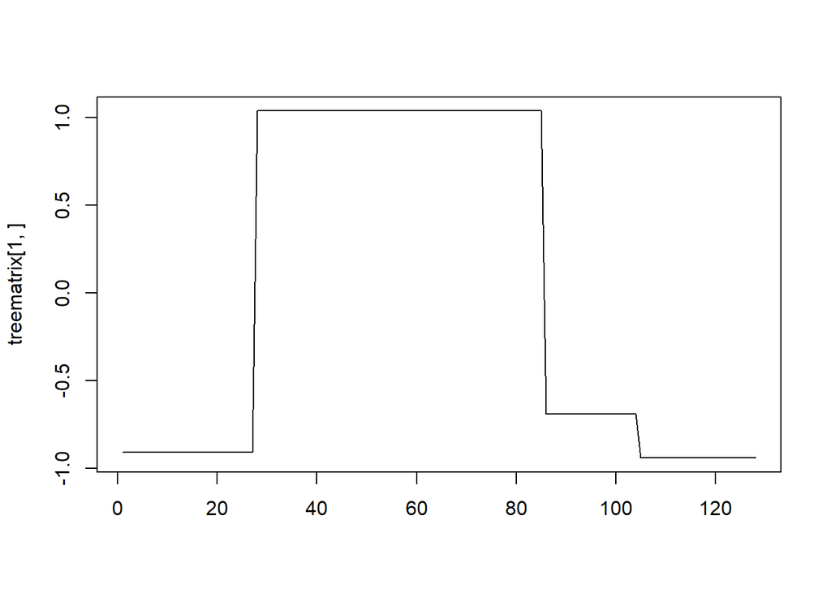

```r
#Predictions are made for classes using neighbors

neighbor_tree <- neighborhood_tree[1]
prediction_tree <- trainclass[neighbor_tree]
treematrix <- as.matrix(tree_rep)

#Plots for regression tree representation and the neighbors are shown below

matplot(treematrix[1,],type='l',col= 1)
```

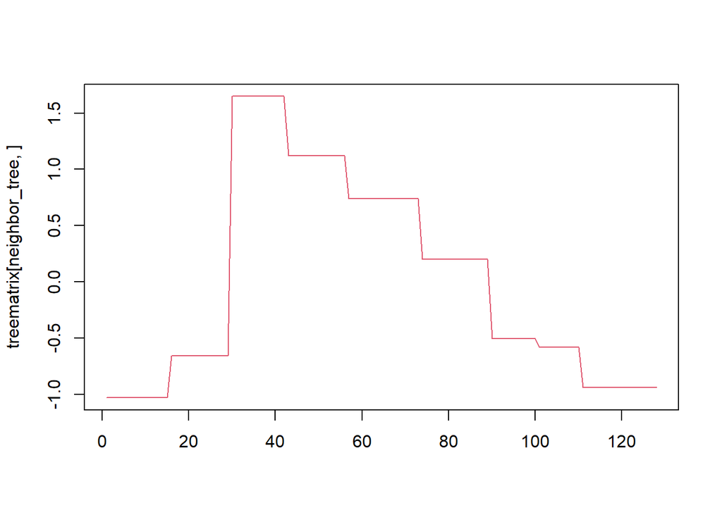

```r
matplot(treematrix[neighbor_tree,],type='l',col= 2)
```

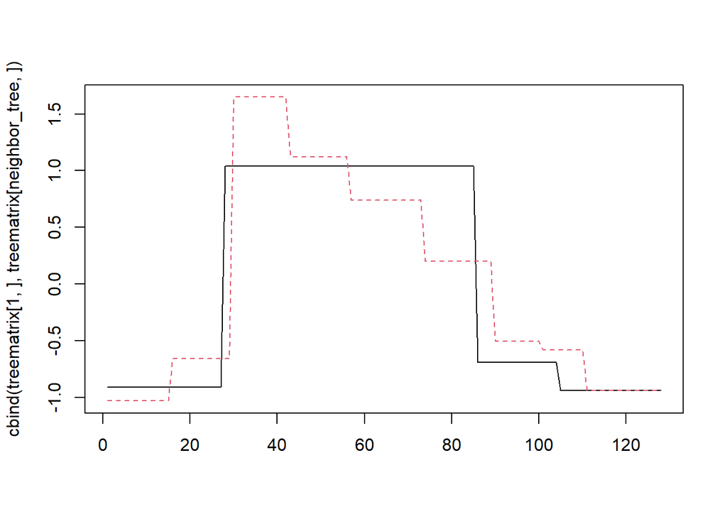

```r
matplot(cbind(treematrix[1,],treematrix[neighbor_tree,]),type='l')
```

```r
#The table representing the number of correct predictions is constructed

neig_tree <- apply(euc_dist_tree,1,order)
pred_tree <- trainclass[neig_tree[1,]]
treetable <- copy(trainclass)
setnames(treetable,'class','actual')
treetable[,predicted:=pred_tree]
treetable$is.correct = ifelse(treetable$predicted==treetable$actual, 1, 0)
table(treetable$actual,treetable$predicted)
```

```
##
##      1  2  3
##   1  8  0  2
##   2  0 12  0
##   3  1  0  7
```

```r
#Accuracy is calculated

acc_tree <- sum(treetable$actual==treetable$predicted)/length(treetable$predicted)
print(acc_tree)
```

```
## [1] 0.9
```

### 1D Fused Lasso Representation

```r
#An empty list and a for loop is formed to keep the prediction data made using regression fused lasso method

fused_rep <- list()

for (i in (1:30)){

  fused_rep[[i]] <- pred_values[[i]]$fused_rep

}

setDT(fused_rep)
fused_rep <- as.data.frame(t(fused_rep))

#Euclidean distances for the predictions made using fused lasso method are calculated and head of the distance matrix is shown

euc_dist_fused <- dist(fused_rep)
euc_dist_fused <- as.matrix(euc_dist_fused)
diag(euc_dist_fused) <- large_number
head(euc_dist_fused)
```

```
##             V1          V2          V3          V4         V5          V6
## V1 1000.000000    7.652124    7.904467   11.046131   14.14541    8.825189
## V2    7.652124 1000.000000    9.450797    9.945549   14.88108   10.029359
## V3    7.904467    9.450797 1000.000000    7.996591   15.95561    6.349780
## V4   11.046131    9.945549    7.996591 1000.000000   15.75246   11.167133
## V5   14.145414   14.881082   15.955610   15.752458 1000.00000   14.414955
## V6    8.825189   10.029359    6.349780   11.167133   14.41496 1000.000000
##           V7        V8        V9       V10       V11       V12       V13
## V1  6.072295 12.348304  8.905342  5.947014  6.120088  7.299113  9.813524
## V2  4.636434  9.267879  8.668917  5.998824  8.808765  9.504340 11.706301
## V3  8.579064  9.901796 13.333334  8.505677  9.400784 10.137615 11.535326
## V4  9.269594  6.689503 14.585869  9.658694 12.488360 13.019649 12.333096
## V5 14.418326 16.615062 11.250260 15.151991 13.785654 13.021715  9.247196
## V6  9.347339 11.569091 11.961211  9.477190  7.984414  8.400904 11.301458
##          V14       V15       V16       V17       V18       V19       V20
## V1  8.680032 14.053546  5.512912 14.529929 12.908926  9.454101 12.529616
## V2  9.367409 15.029135  8.206104 15.486310 13.491086 11.262879 10.001047
## V3 13.495939 16.154756  7.391427 16.927365 15.486610 12.199086 10.266586
## V4 14.613874 15.957730  9.717642 17.014484 15.545102 13.543348  6.195357
## V5 12.444544  1.921227 13.304237  4.062719  6.683907  8.093270 16.675950
## V6 12.187673 14.579185  8.624703 15.138686 14.026419 11.680018 12.220628
##          V21       V22       V23       V24       V25       V26       V27
## V1 15.996345 12.635651  7.218480 10.925307  5.051721  8.018849  7.524147
## V2 16.867003 13.205637  9.506794 13.392078  7.145948  9.826550  9.536898
## V3 17.579331 15.738946 10.535161 13.151897  6.557276  5.895353  6.658793
## V4 16.738931 15.842970 12.402636 14.088791  9.206296  7.549179 11.699196
## V5  8.400314  8.032223 10.532620  8.744423 13.734488 15.007555 13.936247
## V6 15.724554 14.474633 10.738126 12.283697  8.061617  9.067167  4.920088
##          V28       V29       V30
## V1  8.013030  6.958299  6.084719
## V2  9.460216  8.758616  7.459135
## V3  4.189209  5.840287 10.055485
## V4  6.188224  8.018709 12.026611
## V5 15.294237 14.423115 12.525848
## V6  8.181119  7.649875 10.276924
```

```r
#Neighbors of all instances are found and shown below

neighborhood_fused <- order(euc_dist_fused[1,])
neighborhood_fused
```

```
##  [1] 25 16 10  7 30 11 29 23 12 27  2  3 28 26 14  6  9 19 13 24  4  8 20 22 18
## [26] 15  5 17 21  1
```

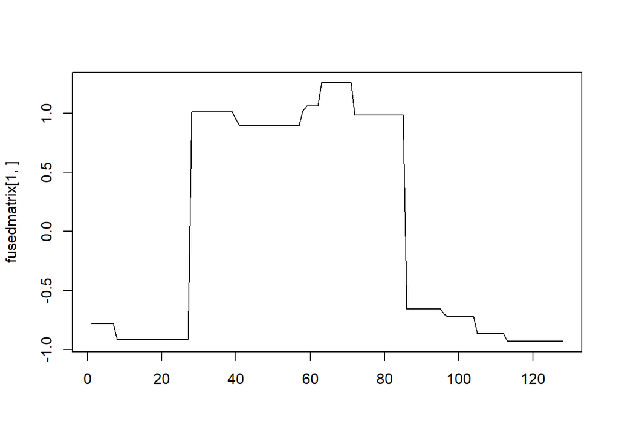

```r
#Predictions are made for classes using neighbors

neighbor_fused <- neighborhood_fused[1]
prediction_fused <- trainclass[neighbor_fused]
fusedmatrix <- as.matrix(fused_rep)

#Plots for fused lasso representation and the neighbors are shown below

matplot(fusedmatrix[1,],type='l',col= 1)
```

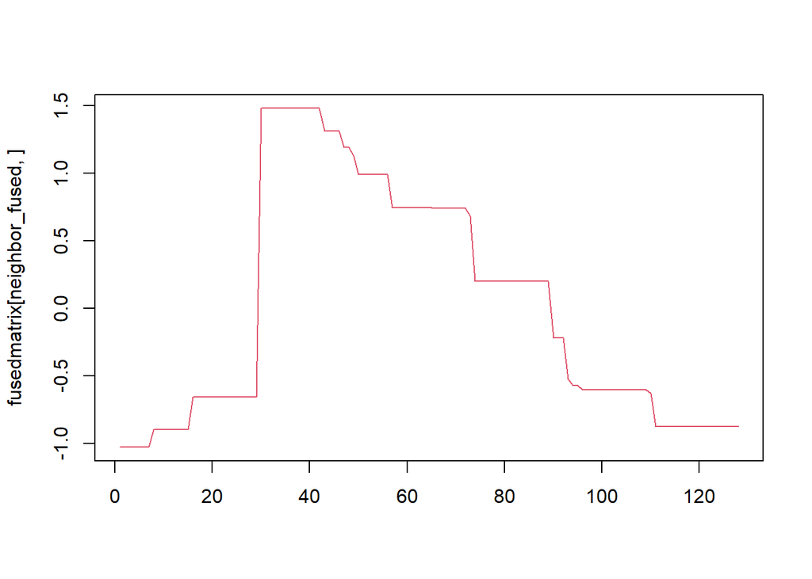

```r
matplot(fusedmatrix[neighbor_fused,],type='l',col= 2)
```

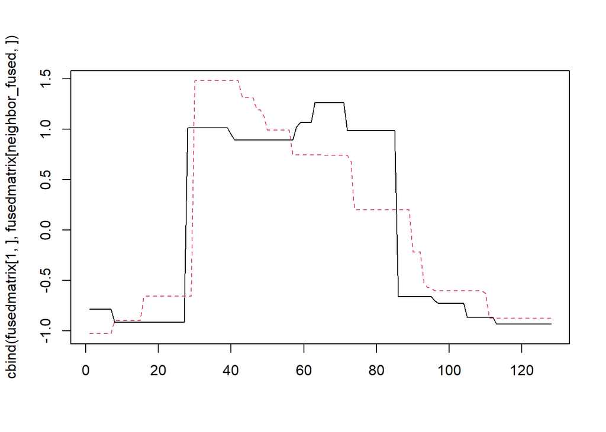

```r
matplot(cbind(fusedmatrix[1,],fusedmatrix[neighbor_fused,]),type='l')
```

```r
#The table representing the number of correct predictions is constructed

neig_fused <- apply(euc_dist_fused,1,order)
pred_fused <- trainclass[neig_fused[1,]]
fusedtable <- copy(trainclass)
setnames(fusedtable,'class','actual')
fusedtable[,predicted:=pred_fused]
fusedtable$is.correct = ifelse(fusedtable$predicted==fusedtable$actual, 1, 0)
table(fusedtable$actual,fusedtable$predicted)
```

```
##
##      1  2  3
##   1  8  0  2
##   2  0 12  0
##   3  0  0  8
```

```r
#Accuracy is calculated

acc_fused <- sum(fusedtable$actual==fusedtable$predicted)/length(fusedtable$predicted)
print(acc_fused)
```

```
## [1] 0.9333333
```

### Conclusion

When the performances of all three classifications are compared using the final accuracy values, it is seen that both representation techniques, regression tree method and fused lasso method, result in an improvement. If the performance of the two representation methods are compared, it can be concluded that fused lasso method provides a better prediction accuracy.